# EasyVisa

[figure not shown]

Artificial Intelligence and Machine Learning

Advanced Machine Learning - Project Debrief

[figure not shown]

Visa Approval Facilitation

## Problem Statement

### Context:

Business communities in the United States are facing high demand for human resources, but one of the constant challenges is identifying and attracting the right talent, which is perhaps the most important element in remaining competitive. Companies in the United States look for hard-working, talented, and qualified individuals both locally as well as abroad.

The Immigration and Nationality Act (INA) of the US permits foreign workers to come to the United States to work on either a temporary or permanent basis. The act also protects US workers against adverse impacts on their wages or working conditions by ensuring US employers' compliance with statutory requirements when they hire foreign workers to fill workforce shortages. The immigration programs are administered by the Office of Foreign Labor Certification (OFLC).

OFLC processes job certification applications for employers seeking to bring foreign workers into the United States and grants certifications in those cases where employers can demonstrate that there are not sufficient US workers available to perform the work at wages that meet or exceed the wage paid for the occupation in the area of intended employment.

### Objective:

In FY 2016, the OFLC processed 775,979 employer applications for 1,699,957 positions for temporary and permanent labor certifications. This was a nine percent increase in the overall number of processed applications from the previous year. The process of reviewing every case is becoming a tedious task as the number of applicants is increasing every year.

The increasing number of applicants every year calls for a Machine Learning based solution that can help in shortlisting the candidates having higher chances of VISA approval. OFLC has hired the firm EasyVisa for data-driven solutions. You as a data scientist at EasyVisa have to analyze the data provided and, with the help of a classification model:

- Facilitate the process of visa approvals.
- Recommend a suitable profile for the applicants for whom the visa should be certified or denied based on the drivers that significantly influence the case status.

### Data Dictionary

The data contains the different attributes of employee and the employer. The detailed data dictionary is given below.

| Column Name | Description |
| --- | --- |
| case_id | ID of each visa application |
| continent | Information of continent the employee |
| education_of_employee | Information of education of the employee |
| has_job_experience | Does the employee have any job experience? Y = Yes; N = No |
| requires_job_training | Does the employee require any job training? Y = Yes; N = No |
| no_of_employees | Number of employees in the employer's company |
| yr_of_estab | Year in which the employer's company was established |
| region_of_employment | Information of foreign worker's intended region of employment in the US |
| prevailing_wage | Average wage paid to similarly employed workers in a specific occupation in the area of intended employment. Ensures foreign workers are not underpaid. |
| unit_of_wage | Unit of prevailing wage. Values include Hourly, Weekly, Monthly, and Yearly. |
| full_time_position | Is the position of work full-time? Y = Full Time Position; N = Part Time Position |
| case_status | Flag indicating if the Visa was certified or denied |

- case_id: unique identifier, may be excluded from modeling although if these are in a sequence, this may be an implicit time series
- continent: review for consistency. (full vs acronym, etc.)
- education_of_employee: check for hierachy. possible ordinal encoding
- has_job_encoding: candidate for binary conversion (0/1). Review for balance
- requires_job_training: candidate for binary conversion (0/1). Review for balance
- no_of_employees: review outliers and consider categorizing
- yr_of_estab: consider converting to age
- region_of_employment: review for method of clustering
- prevailing_wage: in-depth analysis for skew, outliers and distribution
- unit_of_wage: consider method of standardizing
- full_time_position: candidate for binary conversion (0/1). Review for balance
- case_status: Dependent variable. Candidate for binary conversion (0/1). Review for balance. Stratify Splits.

### Business Insights and Objectives

The increasing volume of visa applications highlights a growing bottleneck in the U.S. labor certification process. While the United States continues to be a leading destination for global talent, ensuring a fair, efficient, and legally compliant visa approval process is critical for meeting the workforce demands of U.S. businesses. Employers depend on timely access to skilled international workers, and the Office of Foreign Labor Certification (OFLC) must evaluate these applications in a way that safeguards domestic workers while minimizing delays and administrative burden.

An initial analysis of the application data reveals key business-level insights. Applicants offering higher prevailing wages and those applying for full-time positions are more likely to be approved. Educational background and job experience also appear to be strong indicators of approval success, emphasizing the importance of qualifications. The region of employment and company size may influence approval rates, pointing to potential geographic and organizational trends. On the other hand, applications that result in denial are often associated with lower wages, part-time roles, the absence of prior experience, or the need for job training—highlighting areas where employers can better position their candidates for success.

Given these findings, the business objective is to develop a machine learning-based classification model that can predict the likelihood of visa certification based on applicant and employer attributes. This model would serve to enhance the efficiency of OFLC operations by identifying applications with a high probability of approval or denial, allowing staff to focus attention where it’s needed most. It can also provide employers with actionable insights to improve their applications, such as increasing wages or ensuring applicants meet key experience criteria.

To effectively evaluate the model’s performance, we will focus on the F1-score as the primary metric. Since the target variable (case_status) is binary with a mild class imbalance, and both false positives (predicting approval when it would be denied) and false negatives (predicting denial when it would be approved) have regulatory and business implications, the F1-score offers the best balance between precision and recall. This will ensure that the model minimizes misclassifications in a context where both types of errors carry consequences for employers, employees, and the visa approval system as a whole.

## Importing necessary libraries

```python
!pip show pandas numpy matplotlib seaborn scikit-learn xgboost
```

[output not shown]

[output cut: 1215 more lines]

[output not shown]

**Note**: *After running the above cell, kindly restart the notebook kernel and run all cells sequentially from the below.*

```python
# Libraries to help with reading and manipulating data
import pandas as pd
import numpy as np

# libaries to help with data visualization
import matplotlib.pyplot as plt
import seaborn as sns
import plotly.express as px

# Library to split data
from sklearn.model_selection import train_test_split

# To build model for prediction
from sklearn.tree import DecisionTreeClassifier
from xgboost import XGBClassifier

# for model visualization
from sklearn.metrics import roc_curve, roc_auc_score

# To oversample and undersample data
from imblearn.over_sampling import SMOTE
from imblearn.under_sampling import RandomUnderSampler
from sklearn.model_selection import train_test_split, StratifiedKFold, cross_val_score

# Removes the limit for the number of displayed columns
pd.set_option("display.max_columns", None)

# Sets the limit for the number of displayed rows
pd.set_option("display.max_rows", 100)

# Libraries for different ensemble classifiers
from sklearn.ensemble import (
    BaggingClassifier,
    RandomForestClassifier,
    AdaBoostClassifier,
    GradientBoostingClassifier
)

# Libraries to get different metric scores
from sklearn import metrics
from sklearn.metrics import (
    confusion_matrix,
    accuracy_score,
    precision_score,
    recall_score,
    f1_score,
)

# To tune different models
from sklearn.model_selection import RandomizedSearchCV
from sklearn.model_selection import GridSearchCV

# To ignore unnecessary warnings
import warnings
warnings.filterwarnings("ignore")

# to define a common seed value to be used throughout
RS=0
```

```python
# mount your Google drive to access the data file
from google.colab import drive
drive.mount('/content/drive')
```

## Loading the dataset

```python
# load the visa candidate information from the 'Loan_Modelling.csv' file
visa_data = pd.read_csv("/content/drive/MyDrive/AIML/Projects/EasyVisa/EasyVisa.csv")
```

```python
# setup copy of visa candidate dataset
df = visa_data.copy()
```

## Data Overview

```python
# check head of the dataset
df.head()
```

|  | case_id | continent | education_of_employee | has_job_experience | requires_job_training | no_of_employees | yr_of_estab | region_of_employment | prevailing_wage | unit_of_wage | full_time_position | case_status |
| --- | --- | --- | --- | --- | --- | --- | --- | --- | --- | --- | --- | --- |
| 0 | EZYV01 | Asia | High School | N | N | 14513 | 2007 | West | 592.2029 | Hour | Y | Denied |
| 1 | EZYV02 | Asia | Master's | Y | N | 2412 | 2002 | Northeast | 83425.6500 | Year | Y | Certified |
| 2 | EZYV03 | Asia | Bachelor's | N | Y | 44444 | 2008 | West | 122996.8600 | Year | Y | Denied |
| 3 | EZYV04 | Asia | Bachelor's | N | N | 98 | 1897 | West | 83434.0300 | Year | Y | Denied |
| 4 | EZYV05 | Africa | Master's | Y | N | 1082 | 2005 | South | 149907.3900 | Year | Y | Certified |

**Observations:**

- Looks like a number of columns are in binary form, true/false or yes/no

```python
# check tail of the dataset
df.tail()
```

|  | case_id | continent | education_of_employee | has_job_experience | requires_job_training | no_of_employees | yr_of_estab | region_of_employment | prevailing_wage | unit_of_wage | full_time_position | case_status |
| --- | --- | --- | --- | --- | --- | --- | --- | --- | --- | --- | --- | --- |
| 25475 | EZYV25476 | Asia | Bachelor's | Y | Y | 2601 | 2008 | South | 77092.57 | Year | Y | Certified |
| 25476 | EZYV25477 | Asia | High School | Y | N | 3274 | 2006 | Northeast | 279174.79 | Year | Y | Certified |
| 25477 | EZYV25478 | Asia | Master's | Y | N | 1121 | 1910 | South | 146298.85 | Year | N | Certified |
| 25478 | EZYV25479 | Asia | Master's | Y | Y | 1918 | 1887 | West | 86154.77 | Year | Y | Certified |
| 25479 | EZYV25480 | Asia | Bachelor's | Y | N | 3195 | 1960 | Midwest | 70876.91 | Year | Y | Certified |

**Observations:**

- case_id appears to be sequential

```python
# check shape of the data (size/dimensions)
df.shape
```

```
(25480, 12)
```

**Observations:**

- Data has 25,480 rows
- Data has 12 columns

```python
# check column datatypes
df.info()
```

```
<class 'pandas.core.frame.DataFrame'>
RangeIndex: 25480 entries, 0 to 25479
Data columns (total 12 columns):
 #   Column                 Non-Null Count  Dtype
---  ------                 --------------  -----
 0   case_id                25480 non-null  object
 1   continent              25480 non-null  object
 2   education_of_employee  25480 non-null  object
 3   has_job_experience     25480 non-null  object
 4   requires_job_training  25480 non-null  object
 5   no_of_employees        25480 non-null  int64
 6   yr_of_estab            25480 non-null  int64
 7   region_of_employment   25480 non-null  object
 8   prevailing_wage        25480 non-null  float64
 9   unit_of_wage           25480 non-null  object
 10  full_time_position     25480 non-null  object
 11  case_status            25480 non-null  object
dtypes: float64(1), int64(2), object(9)
memory usage: 2.3+ MB
```

**Observations:**

- Data has 9 columns of object(string) datatype
- Data has 2 columns of int64 datatype, yr_of_estab is a temporal feature
- Data has 1 column of float datatype, prevailing_wage
- No columns are nullable

```python
# check the statistical summary
df.describe(include="all")
```

|  | case_id | continent | education_of_employee | has_job_experience | requires_job_training | no_of_employees | yr_of_estab | region_of_employment | prevailing_wage | unit_of_wage | full_time_position | case_status |
| --- | --- | --- | --- | --- | --- | --- | --- | --- | --- | --- | --- | --- |
| count | 25480 | 25480 | 25480 | 25480 | 25480 | 25480.000000 | 25480.000000 | 25480 | 25480.000000 | 25480 | 25480 | 25480 |
| unique | 25480 | 6 | 4 | 2 | 2 | NaN | NaN | 5 | NaN | 4 | 2 | 2 |
| top | EZYV25480 | Asia | Bachelor's | Y | N | NaN | NaN | Northeast | NaN | Year | Y | Certified |
| freq | 1 | 16861 | 10234 | 14802 | 22525 | NaN | NaN | 7195 | NaN | 22962 | 22773 | 17018 |
| mean | NaN | NaN | NaN | NaN | NaN | 5667.043210 | 1979.409929 | NaN | 74455.814592 | NaN | NaN | NaN |
| std | NaN | NaN | NaN | NaN | NaN | 22877.928848 | 42.366929 | NaN | 52815.942327 | NaN | NaN | NaN |
| min | NaN | NaN | NaN | NaN | NaN | -26.000000 | 1800.000000 | NaN | 2.136700 | NaN | NaN | NaN |
| 25% | NaN | NaN | NaN | NaN | NaN | 1022.000000 | 1976.000000 | NaN | 34015.480000 | NaN | NaN | NaN |
| 50% | NaN | NaN | NaN | NaN | NaN | 2109.000000 | 1997.000000 | NaN | 70308.210000 | NaN | NaN | NaN |
| 75% | NaN | NaN | NaN | NaN | NaN | 3504.000000 | 2005.000000 | NaN | 107735.512500 | NaN | NaN | NaN |
| max | NaN | NaN | NaN | NaN | NaN | 602069.000000 | 2016.000000 | NaN | 319210.270000 | NaN | NaN | NaN |

**Observations:**

| Attribute | Minimum | Average | Maximum |
| --- | --- | --- | --- |
| no_of_employees | -26 | 5667.043210 | 602069.000000 |
| yr_of_estab | 1800 | 1979.409929 | 2016 |
| prevailing_wage | 2.136700 | 74455.814592 | 319210.270000 |

- 4 Dichotomous Variables
- Unexpected (neg) value in no_of_employees
- Potential skew in a number of columns

```python
# check for any missing values
df.isnull().sum()
```

|  | 0 |
| --- | --- |
| case_id | 0 |
| continent | 0 |
| education_of_employee | 0 |
| has_job_experience | 0 |
| requires_job_training | 0 |
| no_of_employees | 0 |
| yr_of_estab | 0 |
| region_of_employment | 0 |
| prevailing_wage | 0 |
| unit_of_wage | 0 |
| full_time_position | 0 |
| case_status | 0 |

**dtype:** int64

**Observations:**

- Data has **NO** missing data values

```python
# check for any duplicate values
df.drop(columns='case_id').duplicated().sum()
```

```
np.int64(0)
```

**Observations:**

- Data has no duplicated data values

## Exploratory Data Analysis (EDA)

#### Exploration Functions

```python
# explore_column
# function to explore a variable's unique values, missing values, descriptive statistics, and value counts
def explore_column(df, column_name):
    print(f"Exploring column: {column_name}")
    print("Unique Values:", df[column_name].nunique())
    print("Missing Values:", df[column_name].isnull().sum())
    print("Descriptive Stats:\n", df[column_name].describe())
    print("Value Counts:\n", df[column_name].value_counts().head(10))
```

#### Column Exploration

##### Exploration of the `case_id` column:

```python
# case_id
explore_column(df, 'case_id')
```

```
Exploring column: case_id
Unique Values: 25480
Missing Values: 0
Descriptive Stats:
 count         25480
unique        25480
top       EZYV25480
freq              1
Name: case_id, dtype: object
Value Counts:
 case_id
EZYV25480    1
EZYV01       1
EZYV02       1
EZYV03       1
EZYV04       1
EZYV05       1
EZYV06       1
EZYV07       1
EZYV25464    1
EZYV25463    1
Name: count, dtype: int64
```

**Observations:**

- The `case_id` column is sequential, based on the initial value of `EZYV01` and the last value of `EZYV25480` along with the total unique values being 25480.

##### Exploration of the `continent` column:

```python
# continent
explore_column(df, 'continent')
```

```
Exploring column: continent
Unique Values: 6
Missing Values: 0
Descriptive Stats:
 count     25480
unique        6
top        Asia
freq      16861
Name: continent, dtype: object
Value Counts:
 continent
Asia             16861
Europe            3732
North America     3292
South America      852
Africa             551
Oceania            192
Name: count, dtype: int64
```

**Observations:**

- The `continent` column is categorical and consists of 6 categories with `Asia` containing the most values with 16861 values
- Significant imbalance with `Asia` taking two thirds of the data
- Candidate for one-hot encoding

##### Exploration of the `education_of_employee` column:

```python
# education_of_employee
explore_column(df, 'education_of_employee')
```

```
Exploring column: education_of_employee
Unique Values: 4
Missing Values: 0
Descriptive Stats:
 count          25480
unique             4
top       Bachelor's
freq           10234
Name: education_of_employee, dtype: object
Value Counts:
 education_of_employee
Bachelor's     10234
Master's        9634
High School     3420
Doctorate       2192
Name: count, dtype: int64
```

**Observations:**

- The `education_of_employee` column is categorical and consists of 4 categories with `Bachelor's` containing the most values with a count of 10,234
- some class imbalance
- candidate for ordinal encoding

##### Exploration of the `has_job_experience` column:

```python
# has_job_experience
explore_column(df, 'has_job_experience')
```

```
Exploring column: has_job_experience
Unique Values: 2
Missing Values: 0
Descriptive Stats:
 count     25480
unique        2
top           Y
freq      14802
Name: has_job_experience, dtype: object
Value Counts:
 has_job_experience
Y    14802
N    10678
Name: count, dtype: int64
```

**Observations:**

- The `has_job_experience` column is in binary form
- Moderately balanced

##### Exploration of the `requires_job_training` column:

```python
# requires_job_training
explore_column(df, 'requires_job_training')
```

```
Exploring column: requires_job_training
Unique Values: 2
Missing Values: 0
Descriptive Stats:
 count     25480
unique        2
top           N
freq      22525
Name: requires_job_training, dtype: object
Value Counts:
 requires_job_training
N    22525
Y     2955
Name: count, dtype: int64
```

**Observations:**

- The `requires_job_training` column is in binary form
- Significant imbalance
- Consider correlation with job experience, education of employee, etc.

##### Exploration of the `no_of_employees` column:

```python
# no_of_employees
explore_column(df, 'no_of_employees')
```

```
Exploring column: no_of_employees
Unique Values: 7105
Missing Values: 0
Descriptive Stats:
 count     25480.000000
mean       5667.043210
std       22877.928848
min         -26.000000
25%        1022.000000
50%        2109.000000
75%        3504.000000
max      602069.000000
Name: no_of_employees, dtype: float64
Value Counts:
 no_of_employees
183     18
854     16
724     16
1476    15
766     15
546     14
169     14
986     14
1666    14
795     14
Name: count, dtype: int64
```

```python
# inspect of suspicious data
df[df['no_of_employees'] < 0]
```

|  | case_id | continent | education_of_employee | has_job_experience | requires_job_training | no_of_employees | yr_of_estab | region_of_employment | prevailing_wage | unit_of_wage | full_time_position | case_status |
| --- | --- | --- | --- | --- | --- | --- | --- | --- | --- | --- | --- | --- |
| 245 | EZYV246 | Europe | Master's | N | N | -25 | 1980 | Northeast | 39452.9900 | Year | Y | Certified |
| 378 | EZYV379 | Asia | Bachelor's | N | Y | -11 | 2011 | Northeast | 32506.1400 | Year | Y | Denied |
| 832 | EZYV833 | South America | Master's | Y | N | -17 | 2002 | South | 129701.9400 | Year | Y | Certified |
| 2918 | EZYV2919 | Asia | Master's | Y | N | -26 | 2005 | Midwest | 112799.4600 | Year | Y | Certified |
| 6439 | EZYV6440 | Asia | Bachelor's | N | N | -14 | 2013 | South | 103.9700 | Hour | Y | Denied |
| 6634 | EZYV6635 | Asia | Bachelor's | Y | N | -26 | 1923 | West | 5247.3200 | Year | Y | Denied |
| 7224 | EZYV7225 | Europe | Doctorate | N | N | -25 | 1998 | Midwest | 141435.9500 | Year | Y | Certified |
| 7281 | EZYV7282 | Asia | High School | N | N | -14 | 2000 | Midwest | 58488.5000 | Year | Y | Denied |
| 7318 | EZYV7319 | Asia | Bachelor's | Y | Y | -26 | 2006 | South | 115005.6100 | Year | Y | Certified |
| 7761 | EZYV7762 | Asia | Master's | N | N | -11 | 2009 | Midwest | 38457.5100 | Year | Y | Certified |
| 9872 | EZYV9873 | Europe | Master's | Y | N | -26 | 1996 | South | 37397.0500 | Year | Y | Certified |
| 11493 | EZYV11494 | Asia | High School | Y | N | -14 | 1999 | South | 27599.3500 | Year | Y | Denied |
| 13471 | EZYV13472 | North America | Master's | N | N | -17 | 2003 | Northeast | 257.2413 | Hour | Y | Denied |
| 14022 | EZYV14023 | Asia | Bachelor's | N | Y | -11 | 1946 | Northeast | 108403.5600 | Year | Y | Certified |
| 14146 | EZYV14147 | Asia | Bachelor's | N | Y | -26 | 1954 | West | 81982.2700 | Year | Y | Certified |
| 14726 | EZYV14727 | Asia | Master's | N | N | -11 | 2000 | Midwest | 167851.8000 | Year | Y | Certified |
| 15600 | EZYV15601 | Asia | Bachelor's | N | N | -14 | 2014 | South | 24641.6100 | Year | Y | Denied |
| 15859 | EZYV15860 | Asia | High School | N | N | -11 | 1969 | South | 44640.6000 | Year | Y | Denied |
| 16157 | EZYV16158 | Asia | Master's | Y | N | -11 | 1994 | South | 62681.2500 | Year | Y | Certified |
| 16883 | EZYV16884 | North America | Bachelor's | Y | N | -26 | 1968 | Northeast | 168.1558 | Hour | Y | Denied |
| 17006 | EZYV17007 | Asia | Doctorate | Y | N | -11 | 1984 | West | 25753.5100 | Year | Y | Denied |
| 17655 | EZYV17656 | North America | Bachelor's | Y | N | -17 | 2007 | Northeast | 129753.1800 | Year | Y | Denied |
| 17844 | EZYV17845 | Asia | Bachelor's | N | N | -14 | 2012 | West | 29325.8500 | Year | Y | Denied |
| 17983 | EZYV17984 | Asia | Bachelor's | N | N | -26 | 2004 | South | 84359.9800 | Year | Y | Denied |
| 20815 | EZYV20816 | Asia | Bachelor's | N | Y | -17 | 1990 | West | 91897.5700 | Year | Y | Certified |
| 20984 | EZYV20985 | Europe | Doctorate | Y | N | -14 | 1989 | Midwest | 37012.8000 | Year | Y | Certified |
| 21255 | EZYV21256 | North America | High School | N | N | -25 | 1987 | South | 99405.4700 | Year | N | Denied |
| 21760 | EZYV21761 | Asia | Bachelor's | Y | N | -25 | 2000 | West | 100463.5800 | Year | Y | Certified |
| 21944 | EZYV21945 | Africa | Master's | Y | N | -25 | 1977 | Midwest | 79150.5100 | Year | Y | Certified |
| 22084 | EZYV22085 | North America | Bachelor's | Y | N | -14 | 1980 | West | 691.0609 | Hour | Y | Denied |
| 22388 | EZYV22389 | Asia | Master's | Y | N | -14 | 1986 | South | 17893.1100 | Year | Y | Certified |
| 23186 | EZYV23187 | Asia | Master's | N | Y | -11 | 2007 | Midwest | 120195.3500 | Year | Y | Certified |
| 23476 | EZYV23477 | Europe | Master's | Y | N | -11 | 2000 | West | 95072.7500 | Year | Y | Denied |

**Observations:**

- The `no_of_employees` column has several characteristics of concern
- Max value of 602,069 is very high and in combination with mean/median, portrays strong positive skew
- Invalid values indicated by negative number of employees, will need to address
- Broad range of values with large variability

##### Exploration of the `yr_of_estab` column:

```python
# yr_of_estab
explore_column(df, 'yr_of_estab')
```

```
Exploring column: yr_of_estab
Unique Values: 199
Missing Values: 0
Descriptive Stats:
 count    25480.000000
mean      1979.409929
std         42.366929
min       1800.000000
25%       1976.000000
50%       1997.000000
75%       2005.000000
max       2016.000000
Name: yr_of_estab, dtype: float64
Value Counts:
 yr_of_estab
1998    1134
2005    1051
2001    1017
2007     994
1999     870
2004     846
2006     844
2000     806
1997     761
2010     743
Name: count, dtype: int64
```

```python
# inspect of suspicious data
df[df['yr_of_estab'] < 1900]
```

|  | case_id | continent | education_of_employee | has_job_experience | requires_job_training | no_of_employees | yr_of_estab | region_of_employment | prevailing_wage | unit_of_wage | full_time_position | case_status |
| --- | --- | --- | --- | --- | --- | --- | --- | --- | --- | --- | --- | --- |
| 3 | EZYV04 | Asia | Bachelor's | N | N | 98 | 1897 | West | 83434.030 | Year | Y | Denied |
| 23 | EZYV24 | North America | High School | N | N | 1517 | 1884 | Midwest | 90108.380 | Year | N | Certified |
| 31 | EZYV32 | Asia | Doctorate | Y | N | 995 | 1880 | South | 135866.130 | Year | N | Certified |
| 67 | EZYV68 | Europe | Doctorate | Y | N | 2070 | 1847 | West | 5319.490 | Year | Y | Certified |
| 73 | EZYV74 | Asia | Master's | Y | N | 452 | 1890 | South | 122540.550 | Year | Y | Certified |
| ... | ... | ... | ... | ... | ... | ... | ... | ... | ... | ... | ... | ... |
| 25444 | EZYV25445 | South America | Master's | Y | N | 1081 | 1838 | Northeast | 156.607 | Hour | Y | Certified |
| 25445 | EZYV25446 | Asia | Bachelor's | Y | N | 2642 | 1890 | Northeast | 25899.990 | Year | Y | Certified |
| 25463 | EZYV25464 | Asia | High School | N | N | 444 | 1838 | Midwest | 213189.360 | Year | Y | Certified |
| 25467 | EZYV25468 | North America | Master's | N | Y | 2504 | 1882 | Northeast | 105900.660 | Year | Y | Certified |
| 25478 | EZYV25479 | Asia | Master's | Y | Y | 1918 | 1887 | West | 86154.770 | Year | Y | Certified |

2108 rows × 12 columns

**Observations:**

- The `yr_of_estab` column has 199 unique values out of 25,480 total, the mean being 1979 and a StdDev of 42.4 years.
- Values indicate a skew for younger organizations
- Candidate for binning into age bands

##### Exploration of the `region_of_employment` column:

```python
# region_of_employment
explore_column(df, 'region_of_employment')
```

```
Exploring column: region_of_employment
Unique Values: 5
Missing Values: 0
Descriptive Stats:
 count         25480
unique            5
top       Northeast
freq           7195
Name: region_of_employment, dtype: object
Value Counts:
 region_of_employment
Northeast    7195
South        7017
West         6586
Midwest      4307
Island        375
Name: count, dtype: int64
```

**Observations:**

- The `region_of_employment` column has 5 unique values and is categorical in nature
- No ordinality between regions noted
- Consider one-hot encoding
- Mild class imbalance, `Island` under represented

##### Exploration of the `prevailing_wage` column:

```python
# prevailing_wage
explore_column(df, 'prevailing_wage')
```

```
Exploring column: prevailing_wage
Unique Values: 25454
Missing Values: 0
Descriptive Stats:
 count     25480.000000
mean      74455.814592
std       52815.942327
min           2.136700
25%       34015.480000
50%       70308.210000
75%      107735.512500
max      319210.270000
Name: prevailing_wage, dtype: float64
Value Counts:
 prevailing_wage
58770.05    2
87751.88    2
134.15      2
60948.15    2
64357.58    2
108.12      2
93356.03    2
118.43      2
113.60      2
88664.77    2
Name: count, dtype: int64
```

```python
# inspect of suspicious data
df[df['prevailing_wage'] < 1000]
```

|  | case_id | continent | education_of_employee | has_job_experience | requires_job_training | no_of_employees | yr_of_estab | region_of_employment | prevailing_wage | unit_of_wage | full_time_position | case_status |
| --- | --- | --- | --- | --- | --- | --- | --- | --- | --- | --- | --- | --- |
| 0 | EZYV01 | Asia | High School | N | N | 14513 | 2007 | West | 592.2029 | Hour | Y | Denied |
| 7 | EZYV08 | North America | Bachelor's | Y | N | 3035 | 1924 | West | 418.2298 | Hour | Y | Denied |
| 54 | EZYV55 | Asia | Master's | Y | N | 11733 | 1995 | Northeast | 230.8072 | Hour | Y | Certified |
| 62 | EZYV63 | Asia | High School | N | N | 5110 | 2004 | West | 103.2216 | Hour | Y | Denied |
| 70 | EZYV71 | Asia | High School | Y | N | 1320 | 2001 | Northeast | 230.3270 | Hour | Y | Denied |
| ... | ... | ... | ... | ... | ... | ... | ... | ... | ... | ... | ... | ... |
| 25444 | EZYV25445 | South America | Master's | Y | N | 1081 | 1838 | Northeast | 156.6070 | Hour | Y | Certified |
| 25450 | EZYV25451 | Asia | Bachelor's | N | N | 3312 | 2009 | Northeast | 682.1048 | Hour | Y | Denied |
| 25461 | EZYV25462 | Asia | Master's | Y | N | 2861 | 2004 | West | 54.9196 | Hour | Y | Denied |
| 25465 | EZYV25466 | North America | High School | N | N | 2577 | 1995 | South | 481.2238 | Hour | Y | Certified |
| 25470 | EZYV25471 | North America | Master's | Y | N | 2272 | 1970 | Northeast | 516.4101 | Hour | Y | Certified |

2267 rows × 12 columns

**Observations:**

- The `prevailing_wage` column has almost all unique values
- Mean: 74,456 with StdDev: 52,815. High variance
- Suspiciously low values, e.g. 2.14. Further investigation shows a number of low values
- Expect a relationship between the low values and the column `unit_of_wage`

##### Exploration of the `unit_of_wage` column:

```python
# unit_of_wage
explore_column(df, 'unit_of_wage')
```

```
Exploring column: unit_of_wage
Unique Values: 4
Missing Values: 0
Descriptive Stats:
 count     25480
unique        4
top        Year
freq      22962
Name: unit_of_wage, dtype: object
Value Counts:
 unit_of_wage
Year     22962
Hour      2157
Week       272
Month       89
Name: count, dtype: int64
```

**Observations:**

- The `unit_of_wage` column is essential in interpreting `prevailing_wage`
- Use to convert `prevailing_wage` to annual wage equivalent

##### Exploration of the `full_time_position` column:

```python
# full_time_position
explore_column(df, 'full_time_position')
```

```
Exploring column: full_time_position
Unique Values: 2
Missing Values: 0
Descriptive Stats:
 count     25480
unique        2
top           Y
freq      22773
Name: full_time_position, dtype: object
Value Counts:
 full_time_position
Y    22773
N     2707
Name: count, dtype: int64
```

**Observations:**

##### Exploration of the `case_status` column:

```python
# case_status
explore_column(df, 'case_status')
```

```
Exploring column: case_status
Unique Values: 2
Missing Values: 0
Descriptive Stats:
 count         25480
unique            2
top       Certified
freq          17018
Name: case_status, dtype: object
Value Counts:
 case_status
Certified    17018
Denied        8462
Name: count, dtype: int64
```

**Observations:**

- The `case_status` column is in binary format, `Certified` and `Denied`
- This is the target variable
- Mildly imbalanced

#### Data Preprocessing: Cleaning, Transformation, and Feature Engineering

##### Clean & Correct Data

For the `case_id` column there is no use in our model so we will drop the column:

```python
# Drop the 'case_id' column
df.drop(["case_id"], axis=1, inplace=True)
```

```python
# handle negative values in no_of_employees
df = df[df['no_of_employees'] >= 0]
```

##### Derived Features

For the `yr_of_estab` column we are going to create a more intuitive value than just a raw calendar year. We will do this by generating a new column `business_age` which is the difference between the year of establishment and this year, 2025

```python
# generate 'business age' from yr_of_estab
df['business_age'] = 2025 - df['yr_of_estab']
```

For the columns `prevailing_wage` and `unit_of_wage` it was determined that we should generate a more standard and consistent value throughout. We will do that by generating a new column `annualized_wage` which is a conversion of `prevailing_wage` dependent on `unit_of_wage` converting to an annualized amount.

```python
# generate 'annualized_wage' from 'prevailing_wage' with 'unit_of_wage'
def convert_to_annual(row):
    wage = row['prevailing_wage']
    unit = row['unit_of_wage']
    if unit == 'Hour':
        return wage * 40 * 52
    elif unit == 'Week':
        return wage * 52
    elif unit == 'Month':
        return wage * 12
    else:
        return wage

df['annualized_wage'] = df.apply(convert_to_annual, axis=1)
```

### Styling and Functions

```python
# variate analysis functions sourced from AIML reference notebooks

# Custom color palette
CUSTOM_PALETTE = ["#FFEBDB", "#FFA364", "#FC7643", "#AF4F41", "#273248"]

# Barplot
def barplot(data, feature, perc=False, n=None):
    """
    Creates a bar plot with labels displaying counts or percentages.

    Parameters:
    - data (pd.DataFrame): The DataFrame containing the data.
    - feature (str): The column in the DataFrame to visualize.
    - perc (bool, optional): If True, displays percentages instead of counts. Default is False.
    - n (int, optional): Number of top categories to display. Default is None (all categories).
    """

    total = len(data[feature])  # Total number of records in the column
    unique_count = data[feature].nunique()

    plt.figure(figsize=(n + 2 if n else unique_count + 2, 6))
    plt.xticks(rotation=90, fontsize=15)

    ax = sns.countplot(
        data=data,
        x=feature,
        palette=CUSTOM_PALETTE,  # Using the updated color palette
        order=data[feature].value_counts().index[:n],
    )

    for p in ax.patches:
        label = f"{100 * p.get_height() / total:.1f}%" if perc else f"{p.get_height()}"
        x, y = p.get_x() + p.get_width() / 2, p.get_height()

        ax.annotate(
            label,
            (x, y),
            ha="center",
            va="center",
            size=12,
            xytext=(0, 5),
            textcoords="offset points",
        )

    plt.show()

# stacked bar plot
def stacked_barplot(data, predictor, target):
    """
    Print the category counts and plot a stacked bar chart

    data: dataframe
    predictor: independent variable
    target: target variable
    """
    count = data[predictor].nunique()
    sorter = data[target].value_counts().index[-1]
    tab1 = pd.crosstab(data[predictor], data[target], margins=True).sort_values(
        by=sorter, ascending=False
    )
    print(tab1)
    print("-" * 120)
    tab = pd.crosstab(data[predictor], data[target], normalize="index").sort_values(
        by=sorter, ascending=False
    )
    tab.plot(kind="bar", stacked=True, figsize=(count + 5, 5))
    plt.legend(
        loc="lower left", frameon=False,
    )
    plt.legend(loc="upper left", bbox_to_anchor=(1, 1))
    plt.show()

# Histogram Boxplot
def histogram_boxplot(data, feature, figsize=(15, 10), kde=False, bins=None):
    """
    Creates a combined boxplot and histogram for a given feature.

    Parameters:
    - data (pd.DataFrame): The DataFrame containing the data.
    - feature (str): The column in the DataFrame to visualize.
    - figsize (tuple, optional): Figure size. Default is (15, 10).
    - kde (bool, optional): Whether to show the density curve. Default is False.
    - bins (int, optional): Number of bins for the histogram. Default is None.
    """

    # Create subplots with a 2-row layout, sharing the x-axis
    fig, (ax_box, ax_hist) = plt.subplots(
        nrows=2,
        sharex=True,
        gridspec_kw={"height_ratios": (0.25, 0.75)},
        figsize=figsize
    )

    # Boxplot with updated color
    sns.boxplot(
        data=data, x=feature, ax=ax_box, showmeans=True, color="#FC7643"  # Crusta
    )

    # Histogram with density curve if enabled
    sns.histplot(
        data=data, x=feature, kde=kde, ax=ax_hist, bins=bins
    ) if bins else sns.histplot(
        data=data, x=feature, kde=kde, ax=ax_hist
    )

    # Add vertical lines for mean and median with updated colors
    ax_hist.axvline(
        data[feature].mean(), color="#FFA364", linestyle="--", label="Mean"  # Atomic Tangerine
    )
    ax_hist.axvline(
        data[feature].median(), color="#273248", linestyle="-", label="Median"  # Pickled Bluewood
    )

    ax_hist.legend()  # Show legend for mean/median lines
    plt.show()

# Correlation Heatmap
def correlation_heatmap(data, figsize=(12, 8), annot=True, cmap="coolwarm"):
    """
    Generates a correlation heatmap for numerical features.

    Parameters:
    - data (pd.DataFrame): The DataFrame containing numerical features.
    - figsize (tuple, optional): Figure size. Default is (12, 8).
    - annot (bool, optional): Whether to display correlation values. Default is True.
    - cmap (str, optional): Colormap for heatmap. Default is "coolwarm".
    """

    plt.figure(figsize=figsize)
    sns.heatmap(
        data.corr(),
        annot=annot,
        cmap=["#FFEBDB", "#FFA364", "#FC7643", "#AF4F41", "#273248"],  # Custom color palette
        linewidths=0.5,
        linecolor="#273248",  # Pickled Bluewood for grid lines
        fmt=".2f"
    )

    plt.title("Correlation Heatmap", fontsize=14, color="#273248")  # Pickled Bluewood
    plt.show()

# Violin Plot
def violin_plot(data, feature, target, figsize=(12, 6)):
    """
    Generates a violin plot for feature distribution across target categories.

    Parameters:
    - data (pd.DataFrame): The DataFrame containing the data.
    - feature (str): The numerical feature to visualize.
    - target (str): The categorical column for grouping.
    - figsize (tuple, optional): Figure size. Default is (12, 6).
    """

    plt.figure(figsize=figsize)
    sns.violinplot(
        data=data,
        x=target,
        y=feature,
        palette=["#FFEBDB", "#FFA364", "#FC7643", "#AF4F41", "#273248"],  # Custom color scheme
        inner="quartile"
    )

    plt.title(f"Violin Plot of {feature} by {target}", fontsize=14, color="#273248")  # Pickled Bluewood
    plt.xlabel(target, fontsize=12, color="#273248")  # X-axis label
    plt.ylabel(feature, fontsize=12, color="#273248")  # Y-axis label
    plt.show()

# Distribution Plot
def distribution_plot_wrt_target(data, predictor, target):
    """
    Plots the distribution of a predictor variable with respect to a target variable.

    Parameters:
    data (pd.DataFrame): The dataset containing the predictor and target variables.
    predictor (str): The column name of the predictor variable.
    target (str): The column name of the target variable.
    """

    fig, axs = plt.subplots(2, 2, figsize=(12, 10))

    # Unique target values
    target_uniq = data[target].unique()

    # Distribution plots for each target value
    axs[0, 0].set_title(f"Distribution of {predictor} for {target} = {target_uniq[0]}")
    sns.histplot(
        data=data[data[target] == target_uniq[0]],
        x=predictor,
        kde=True,
        ax=axs[0, 0],
        color="#FFA364",  # Atomic Tangerine
        stat="density",
    )

    axs[0, 1].set_title(f"Distribution of {predictor} for {target} = {target_uniq[1]}")
    sns.histplot(
        data=data[data[target] == target_uniq[1]],
        x=predictor,
        kde=True,
        ax=axs[0, 1],
        color="#FC7643",  # Crusta
        stat="density",
    )

    # Boxplots
    axs[1, 0].set_title("Boxplot w.r.t target")
    sns.boxplot(
        data=data,
        x=target,
        y=predictor,
        ax=axs[1, 0],
        palette=["#AF4F41", "#FFA364"],  # Apple Blossom & Atomic Tangerine
    )

    axs[1, 1].set_title("Boxplot (without outliers) w.r.t target")
    sns.boxplot(
        data=data,
        x=target,
        y=predictor,
        ax=axs[1, 1],
        showfliers=False,
        palette=["#AF4F41", "#FFA364"],  # Apple Blossom & Atomic Tangerine
    )

    # Final layout adjustments
    plt.tight_layout()
    plt.show()

def plot_numeric_outliers_boxplots(dataframe):
    """
    Generate boxplots for all numeric columns in the given DataFrame
    to visually detect outliers.

    Parameters:
        dataframe (pd.DataFrame): The input DataFrame containing numeric columns.
    """
    numeric_columns = dataframe.select_dtypes(include=np.number).columns.tolist()

    num_plots = len(numeric_columns)
    num_cols = 4  # You can adjust the number of columns per row
    num_rows = (num_plots + num_cols - 1) // num_cols

    plt.figure(figsize=(num_cols * 4, num_rows * 3))

    for i, variable in enumerate(numeric_columns):
        plt.subplot(num_rows, num_cols, i + 1)
        plt.boxplot(dataframe[variable].dropna(), whis=1.5)
        plt.title(variable)
        plt.tight_layout()

    plt.show()
```

### Univariate Analysis

#### Observations on `prevailing_wage`

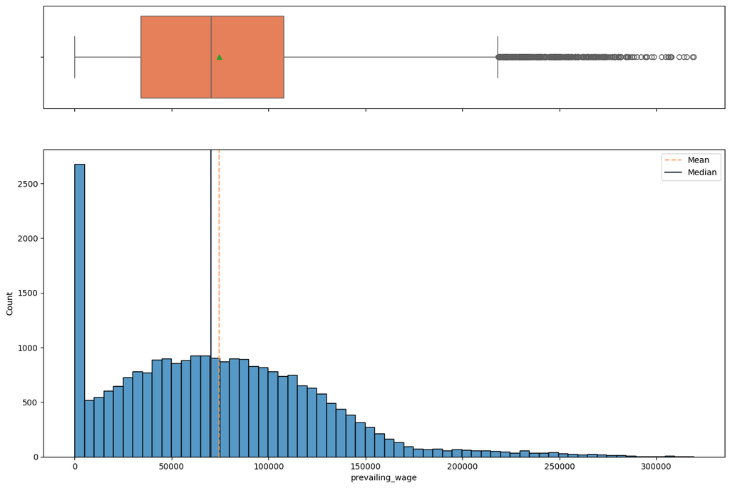

```python
# Histogram Boxplot of prevailing_wage
histogram_boxplot(df, "prevailing_wage")
```

**Observations:**

- `prevailing_wage` distribution appears to be right skewed
- There are a number of outliers present in the data but are consistent
- Large amount of `low` values as annotated in the exploration of this column

#### Observations on `annualized_wage`

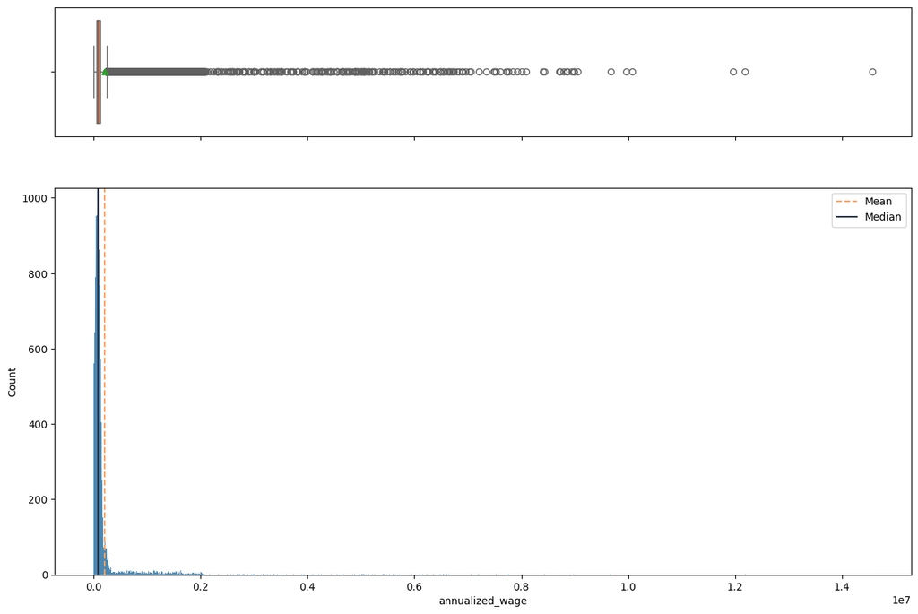

```python
# Histogram Boxplot of annualized_wage
histogram_boxplot(df, "annualized_wage")
```

**Observations:**

- `annualized_wage` distribution appears to be heavily right-skewed, with most data concentrated near the lower end.
- There are a substantial number of outliers, as shown in the boxplot, indicating some very high wage values far above the upper whisker.
- A large volume of low wage values are present, consistent with the earlier exploration of this column and the histogram showing a sharp peak near the lower end.
- The mean is noticeably higher than the median, confirming the skew and the influence of outliers pulling the average upward.

#### Observations on `no_of_employees`

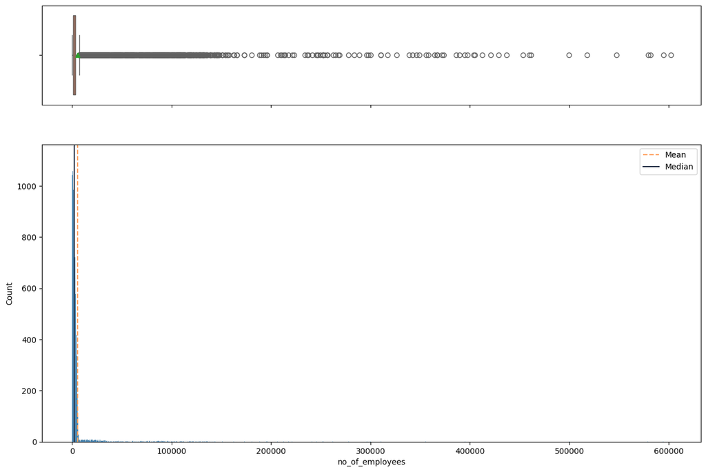

```python
# Histogram Boxplot of no_of_employees
histogram_boxplot(df, "no_of_employees")
```

**Observations:**

- `no_of_employees` distribution appears to be heavily right-skewed, with most data concentrated near the lower end.
- Again, there are a substantial number of outliers, as shown in the boxplot, indicating some very employee count values far above the upper whisker.

#### Observations on `business_age`

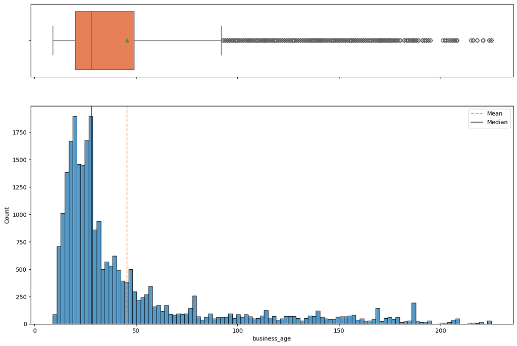

```python
# Histogram Boxplot of business_age
histogram_boxplot(df, "business_age")
```

**Observations:**

- `business_age` distribution is right-skewed, with most businesses being relatively young and a long tail extending toward much older companies.
- There are a considerable number of outliers representing businesses older than 100 years, as shown in the boxplot.
- A large number of businesses fall into the lower age range (under 50 years), consistent with the peak seen in the histogram.

#### Observations on`education_of_employee`

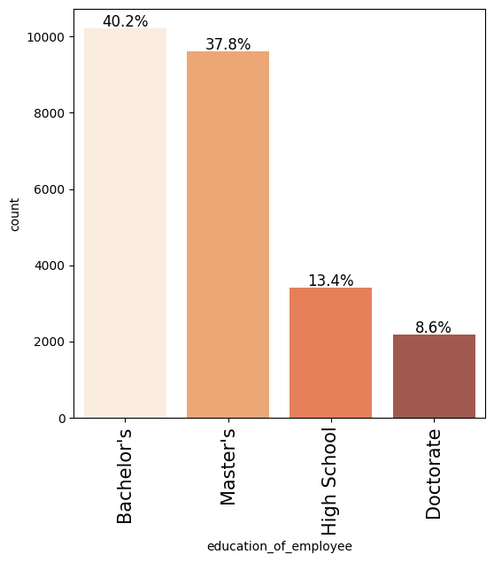

```python
# Bar Plot of education_of_employee
barplot(df, "education_of_employee", perc=True)
```

**Observations:**

- `education_of_employee` distribution is concentrated in higher education with the lower two out of four categories only populating 22% of the data set.
- The data is skewed toward advanced education, which could influence visa approval likelihood or wage levels in later analysis.

#### Observations on `region_of_employment`

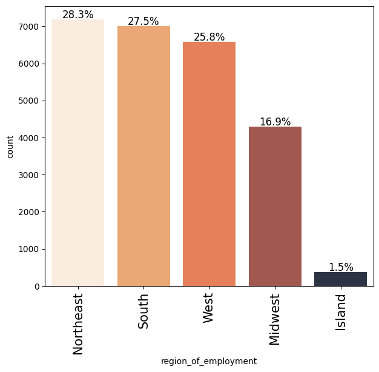

```python
# Bar Plot of region_of_employment
barplot(df, "region_of_employment", perc=True)
```

Observations:

- `region_of_employment` is relatively balanced across major regions, with the Northeast (28.3%), South (27.5%), and West (25.8%) accounting for the majority of records.
- `Island` region represents only 1.5% of the data, indicating a significant underrepresentation.
- The skew toward the top three regions could affect model interpretation if region-specific effects are significant

#### Observations on `has_job_experience`

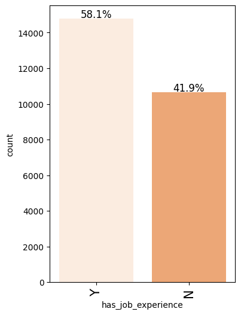

```python
# Bar Plot of has_job_experience
barplot(df, "has_job_experience", perc=True)
```

Observations:

- `has_job_experience` is moderately imbalanced with 58.1% having and 41.9% not having experience.
- This variable is cleanly categorized as binary (Y/N) and ready for transformation into numeric format (e.g., 1/0) for modeling.

#### Observations on `case_status`

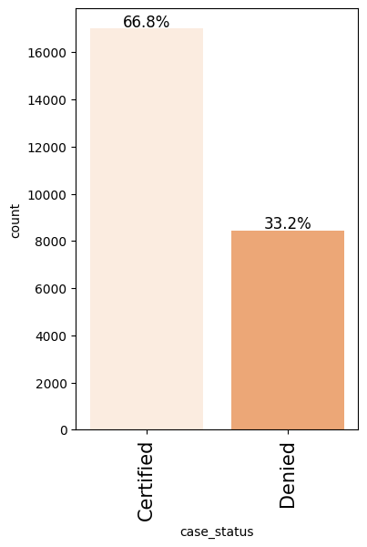

```python
# Bar Plot of case_status
barplot(df, "case_status", perc=True)
```

Observations:

- `case_status` the target variable, shows a moderate class imbalance with 66.8% of applications being Certified and 33.2% being Denied.
- it is significant enough to potentially bias some classification models toward predicting the majority class.
- This distribution highlights the importance of using evaluation metrics such as F1-score, precision, and recall, rather than accuracy alone, to properly assess model performance.
- Stratified sampling should be used when splitting the dataset into training and testing sets to maintain this proportion in both subsets.
- Techniques such as class weighting, SMOTE (Synthetic Minority Oversampling Technique), or undersampling may be considered depending on model behavior during training.

### Bivariate Analysis

#### Observations on variable correlation

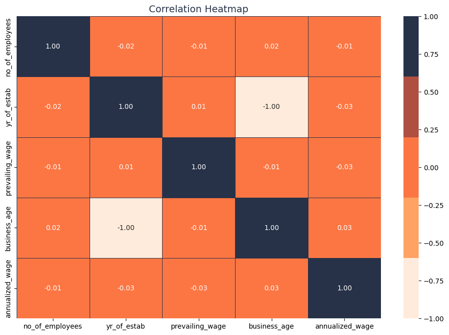

```python
# Correlation Heatmap
correlation_heatmap(df.select_dtypes(include=['number']))
```

Observations:

#### Observations on `education_of_employee` correlation with `case_study`

```
case_status            Certified  Denied    All
education_of_employee
All                        17001    8446  25447
Bachelor's                  6362    3858  10220
High School                 1164    2252   3416
Master's                    7565    2057   9622
Doctorate                   1910     279   2189
------------------------------------------------------------------------------------------------------------------------
```

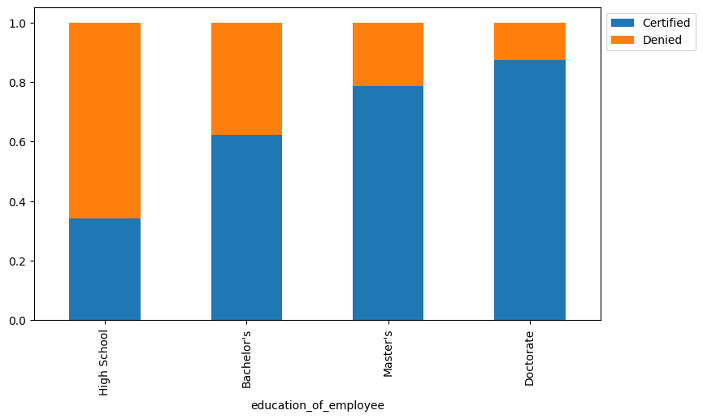

```python
# Create a stacked bar plot to compare visa case outcomes (Certified vs Denied) across different educations
stacked_barplot(df, "education_of_employee", "case_status")
```

Observations:

- Education demonstrate a clear correlation with certification.
- This pattern suggests that educational attainment is a significant predictor in visa decisions and should be considered a key feature during modeling.

#### Observations on `region_of_employment` correlation with `case_study`

```
case_status           Certified  Denied    All
region_of_employment
All                       17001    8446  25447
Northeast                  4524    2665   7189
West                       4097    2481   6578
South                      4908    2098   7006
Midwest                    3246    1053   4299
Island                      226     149    375
------------------------------------------------------------------------------------------------------------------------
```

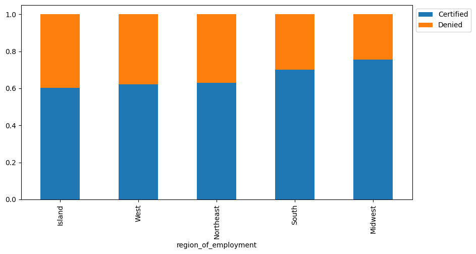

```python
# Create a stacked bar plot to compare visa case outcomes (Certified vs Denied) across different continents
stacked_barplot(df, "region_of_employment", "case_status")
```

Observations:

- Region appears to have a moderate influence on certification.